# AE 17: Multicollinearity

Rail Trail

**Important**

## Packages + data

```r
library(tidyverse)
library(ggformula)
library(GGally)
library(broom)
library(knitr)
library(mosaic)
library(mosaicData)

rail_trail <- read_csv("../data/rail_trail.csv")
```

The data for this AE is based on data from the Pioneer Valley Planning Commission (PVPC) and is included in the **mosaicData** package. The PVPC collected data for ninety days from April 5, 2005 to November 15, 2005. Data collectors set up a laser sensor, with breaks in the laser beam recording when a rail-trail user passed the data collection station. More information can be found [here](http://www.fvgreenway.org/pdfs/Northampton-Bikepath-Volume-Counts%20_05_LTA.pdf).

## Analysis goal

The goals of this activity are to:

- Detect and remedy multicollinearity in our data

## Exercise 0

Fit a linear model to predict `volume` from ALL of the other predictors. The resulting model is called the “full model”.

## Exercise 1

Create a new data frame called `rail_trail_new` with two new columns, `hightemp_c` and `avgtemp_c`. These two new columns should store the `hightemp` and `avgtemp` measured in Celsius rather than Fahrenheit. Note that the formula to convert between Fahrenheit and Celsius is $C = (F-32)\times \frac{5}{9}$. Make sure `hightemp` and `avgtemp` are still in your data set.

## Exercise 2

Try to refit the full model on your data. Do you notice anything odd about your coefficients? If so, what do you think is happening?

## Exercise 3

Add a comment next to each line of code explaining what that line of code is doing.

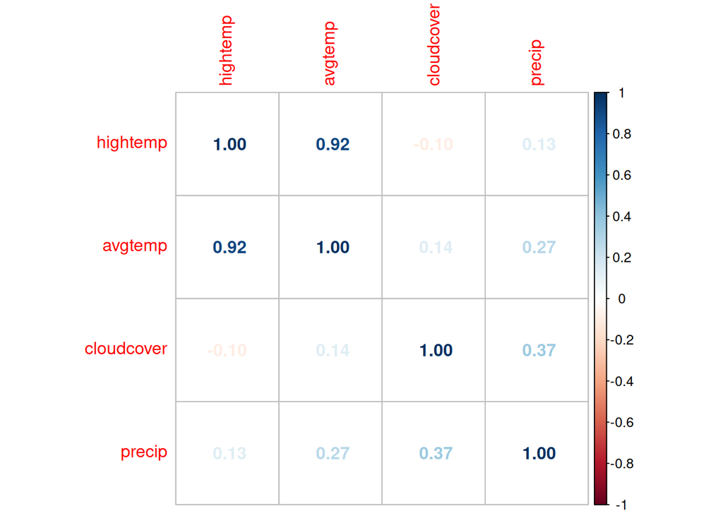

```r
library(corrplot)

rail_trail |> # Take the rail_trail data set and then
  select(-volume) |> # What do I do
  select(where(is.numeric)) |> # What do I do
  cor() |>   # What do I do
  corrplot(method="number") # What do I do
```

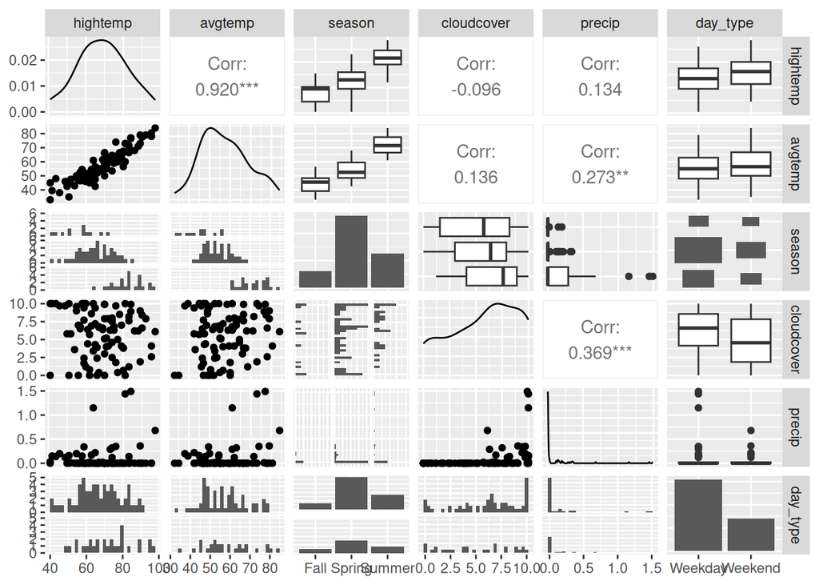

```r
rail_trail |>
  select(-volume) |> # What do I do
  ggpairs()
```

## Exercise 4

Based on the output from the previous exercise, do you have reason to believe that our data is exhibiting multicollinearity?

## Exercise 5

Pipe the model you fit in Exercise 0 (i.e. not including the variable measured in Celcius) into the function `vif`. Are any of the vif’s concerning? If so, which ones.

## Exercise 6

- `m1`: use all predictors except for `avgtemp`
- `m2`: use all predictors except for `hightemp`
- `m3`: average `avgtemp` and `hightemp` together and use it instead of either `avgtemp` and `hightemp`

## To submit the AE

**Important**

- Render the document to produce the PDF with all of your work from today’s class.
- Upload your QMD and PDF files to the Canvas assignment.